# Risk Factor Analysis

## Outcome Variable

**Outcome Variable:** wasted

## Predictor Variables

**Intervention Variable:** predexfd6

**Adjustment Set:**

- arm
- sex
- brthmon
- W_mage
- meducyrs
- feducyrs
- hhwealth_quart
- hfoodsec
- W_mhtcm
- W_mwtkg
- W_mbmi
- vagbrth
- W_gagebrth
- W_birthwt
- W_birthlen
- W_nrooms
- W_nchldlt5
- month
- W_parity
- impfloor
- impsan
- safeh20
- delta_W_mage
- delta_meducyrs
- delta_feducyrs
- delta_hhwealth_quart
- delta_hfoodsec
- delta_W_mhtcm
- delta_W_mwtkg
- delta_W_mbmi
- delta_vagbrth
- delta_W_gagebrth
- delta_W_birthwt
- delta_W_birthlen
- delta_W_nrooms
- delta_W_nchldlt5
- delta_month
- delta_W_parity
- delta_impfloor
- delta_impsan
- delta_safeh20

## Stratifying Variables

The analysis was stratified on these variable(s):

- agecat
- studyid
- country

## Data Summary

| agecat | studyid | country | predexfd6 | wasted | n_cell | n |
| --- | --- | --- | --- | --- | --- | --- |
| Birth | CMC-V-BCS-2002 | INDIA | 1 | 0 | 7 | 7 |
| Birth | CMC-V-BCS-2002 | INDIA | 1 | 1 | 0 | 7 |
| Birth | CMC-V-BCS-2002 | INDIA | 0 | 0 | 0 | 7 |
| Birth | CMC-V-BCS-2002 | INDIA | 0 | 1 | 0 | 7 |
| Birth | EE | PAKISTAN | 1 | 0 | 20 | 28 |
| Birth | EE | PAKISTAN | 1 | 1 | 4 | 28 |
| Birth | EE | PAKISTAN | 0 | 0 | 3 | 28 |
| Birth | EE | PAKISTAN | 0 | 1 | 1 | 28 |
| Birth | GMS-Nepal | NEPAL | 1 | 0 | 309 | 522 |
| Birth | GMS-Nepal | NEPAL | 1 | 1 | 81 | 522 |
| Birth | GMS-Nepal | NEPAL | 0 | 0 | 111 | 522 |
| Birth | GMS-Nepal | NEPAL | 0 | 1 | 21 | 522 |
| Birth | IRC | INDIA | 1 | 0 | 0 | 12 |
| Birth | IRC | INDIA | 1 | 1 | 0 | 12 |
| Birth | IRC | INDIA | 0 | 0 | 8 | 12 |
| Birth | IRC | INDIA | 0 | 1 | 4 | 12 |
| Birth | JiVitA-3 | BANGLADESH | 1 | 0 | 7437 | 10744 |
| Birth | JiVitA-3 | BANGLADESH | 1 | 1 | 955 | 10744 |
| Birth | JiVitA-3 | BANGLADESH | 0 | 0 | 2112 | 10744 |
| Birth | JiVitA-3 | BANGLADESH | 0 | 1 | 240 | 10744 |
| Birth | JiVitA-4 | BANGLADESH | 1 | 0 | 1626 | 2224 |
| Birth | JiVitA-4 | BANGLADESH | 1 | 1 | 176 | 2224 |
| Birth | JiVitA-4 | BANGLADESH | 0 | 0 | 375 | 2224 |
| Birth | JiVitA-4 | BANGLADESH | 0 | 1 | 47 | 2224 |
| Birth | Keneba | GAMBIA | 1 | 0 | 351 | 1327 |
| Birth | Keneba | GAMBIA | 1 | 1 | 99 | 1327 |
| Birth | Keneba | GAMBIA | 0 | 0 | 645 | 1327 |
| Birth | Keneba | GAMBIA | 0 | 1 | 232 | 1327 |
| Birth | MAL-ED | BANGLADESH | 1 | 0 | 58 | 194 |
| Birth | MAL-ED | BANGLADESH | 1 | 1 | 10 | 194 |

[output cut: 170 more lines]

The following strata were considered:

- agecat: 24 months, studyid: CMC-V-BCS-2002, country: INDIA
- agecat: 24 months, studyid: EE, country: PAKISTAN
- agecat: 24 months, studyid: GMS-Nepal, country: NEPAL
- agecat: 24 months, studyid: IRC, country: INDIA
- agecat: 24 months, studyid: JiVitA-3, country: BANGLADESH
- agecat: 24 months, studyid: JiVitA-4, country: BANGLADESH
- agecat: 24 months, studyid: Keneba, country: GAMBIA
- agecat: 24 months, studyid: LCNI-5, country: MALAWI
- agecat: 24 months, studyid: MAL-ED, country: BANGLADESH
- agecat: 24 months, studyid: MAL-ED, country: BRAZIL
- agecat: 24 months, studyid: MAL-ED, country: INDIA
- agecat: 24 months, studyid: MAL-ED, country: NEPAL
- agecat: 24 months, studyid: MAL-ED, country: PERU
- agecat: 24 months, studyid: MAL-ED, country: SOUTH AFRICA
- agecat: 24 months, studyid: MAL-ED, country: TANZANIA, UNITED REPUBLIC OF
- agecat: 24 months, studyid: PROVIDE, country: BANGLADESH
- agecat: 6 months, studyid: CMC-V-BCS-2002, country: INDIA
- agecat: 6 months, studyid: EE, country: PAKISTAN
- agecat: 6 months, studyid: GMS-Nepal, country: NEPAL
- agecat: 6 months, studyid: IRC, country: INDIA
- agecat: 6 months, studyid: JiVitA-3, country: BANGLADESH
- agecat: 6 months, studyid: JiVitA-4, country: BANGLADESH
- agecat: 6 months, studyid: Keneba, country: GAMBIA
- agecat: 6 months, studyid: LCNI-5, country: MALAWI
- agecat: 6 months, studyid: MAL-ED, country: BANGLADESH
- agecat: 6 months, studyid: MAL-ED, country: BRAZIL
- agecat: 6 months, studyid: MAL-ED, country: INDIA
- agecat: 6 months, studyid: MAL-ED, country: NEPAL
- agecat: 6 months, studyid: MAL-ED, country: PERU
- agecat: 6 months, studyid: MAL-ED, country: SOUTH AFRICA
- agecat: 6 months, studyid: MAL-ED, country: TANZANIA, UNITED REPUBLIC OF
- agecat: 6 months, studyid: PROVIDE, country: BANGLADESH
- agecat: 6 months, studyid: SAS-CompFeed, country: INDIA
- agecat: 6 months, studyid: SAS-FoodSuppl, country: INDIA
- agecat: Birth, studyid: CMC-V-BCS-2002, country: INDIA
- agecat: Birth, studyid: EE, country: PAKISTAN
- agecat: Birth, studyid: GMS-Nepal, country: NEPAL
- agecat: Birth, studyid: IRC, country: INDIA
- agecat: Birth, studyid: JiVitA-3, country: BANGLADESH
- agecat: Birth, studyid: JiVitA-4, country: BANGLADESH
- agecat: Birth, studyid: Keneba, country: GAMBIA
- agecat: Birth, studyid: MAL-ED, country: BANGLADESH
- agecat: Birth, studyid: MAL-ED, country: BRAZIL
- agecat: Birth, studyid: MAL-ED, country: INDIA
- agecat: Birth, studyid: MAL-ED, country: NEPAL
- agecat: Birth, studyid: MAL-ED, country: PERU
- agecat: Birth, studyid: MAL-ED, country: SOUTH AFRICA
- agecat: Birth, studyid: MAL-ED, country: TANZANIA, UNITED REPUBLIC OF
- agecat: Birth, studyid: PROVIDE, country: BANGLADESH
- agecat: Birth, studyid: SAS-CompFeed, country: INDIA

### Dropped Strata

Some strata were dropped due to rare outcomes:

- agecat: Birth, studyid: CMC-V-BCS-2002, country: INDIA
- agecat: Birth, studyid: EE, country: PAKISTAN
- agecat: Birth, studyid: IRC, country: INDIA
- agecat: Birth, studyid: MAL-ED, country: BRAZIL
- agecat: Birth, studyid: MAL-ED, country: INDIA
- agecat: Birth, studyid: MAL-ED, country: NEPAL
- agecat: Birth, studyid: MAL-ED, country: PERU
- agecat: Birth, studyid: MAL-ED, country: SOUTH AFRICA
- agecat: Birth, studyid: MAL-ED, country: TANZANIA, UNITED REPUBLIC OF
- agecat: Birth, studyid: SAS-CompFeed, country: INDIA
- agecat: 6 months, studyid: CMC-V-BCS-2002, country: INDIA
- agecat: 6 months, studyid: EE, country: PAKISTAN
- agecat: 6 months, studyid: IRC, country: INDIA
- agecat: 6 months, studyid: LCNI-5, country: MALAWI
- agecat: 6 months, studyid: MAL-ED, country: BANGLADESH
- agecat: 6 months, studyid: MAL-ED, country: BRAZIL
- agecat: 6 months, studyid: MAL-ED, country: INDIA
- agecat: 6 months, studyid: MAL-ED, country: NEPAL
- agecat: 6 months, studyid: MAL-ED, country: PERU
- agecat: 6 months, studyid: MAL-ED, country: SOUTH AFRICA
- agecat: 6 months, studyid: MAL-ED, country: TANZANIA, UNITED REPUBLIC OF
- agecat: 6 months, studyid: PROVIDE, country: BANGLADESH
- agecat: 6 months, studyid: SAS-CompFeed, country: INDIA
- agecat: 6 months, studyid: SAS-FoodSuppl, country: INDIA
- agecat: 24 months, studyid: CMC-V-BCS-2002, country: INDIA
- agecat: 24 months, studyid: EE, country: PAKISTAN
- agecat: 24 months, studyid: IRC, country: INDIA
- agecat: 24 months, studyid: LCNI-5, country: MALAWI
- agecat: 24 months, studyid: MAL-ED, country: BRAZIL
- agecat: 24 months, studyid: MAL-ED, country: INDIA
- agecat: 24 months, studyid: MAL-ED, country: NEPAL
- agecat: 24 months, studyid: MAL-ED, country: PERU
- agecat: 24 months, studyid: MAL-ED, country: SOUTH AFRICA
- agecat: 24 months, studyid: MAL-ED, country: TANZANIA, UNITED REPUBLIC OF

## Methods Detail

We’re interested in the causal parameters $E[Y_a]$ for all values of $a \in \mathcal{A}$. These parameters represent the mean outcome if, possibly contrary to fact, we intervened to set all units to have $A=a$. Under the randomization and positivity assumptions, these are identified by the statistical parameters $\psi_a=E_W[E_{Y|A,W}(Y|A=a,W)]$. In addition, we’re interested in the mean of $Y$, $E[Y]$ under no intervention (the observed mean). We will estimate these parameters by using SuperLearner to fit the relevant likelihood factors – $E_{Y|A,W}(Y|A=a,W)$ and $p(A=a|W)$, and then updating our likelihood fit using a joint TMLE.

For unadjusted analyses ($W=\{\}$), initial likelihoods were estimated using Lrnr_glm to estimate the simple $E(Y|A)$ and Lrnr_mean to estimate $p(A)$. For adjusted analyses, a small library containing Lrnr_glmnet, Lrnr_xgboost, and Lrnr_mean was used.

Having estimated these parameters, we will then use the delta method to estimate relative risks and attributable risks relative to a prespecified baseline level of $A$.

# Results Detail

## Results Plots

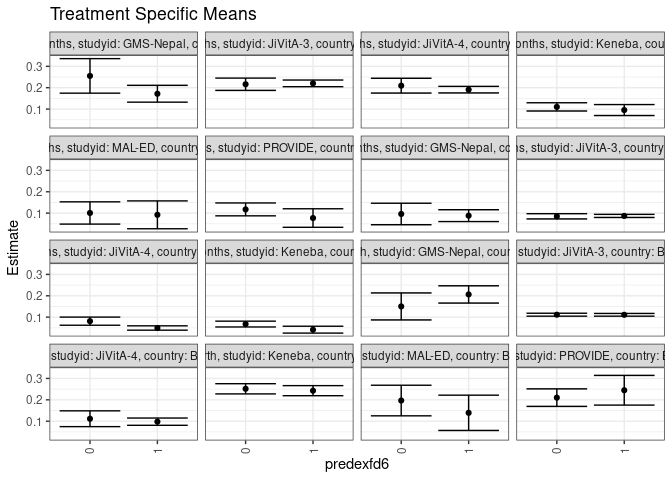

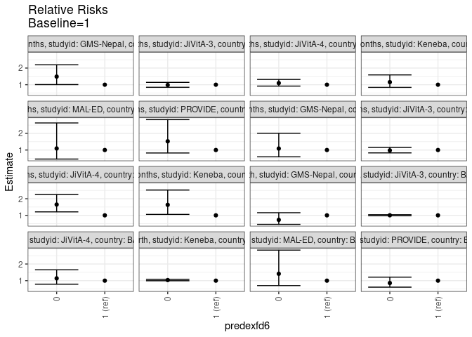

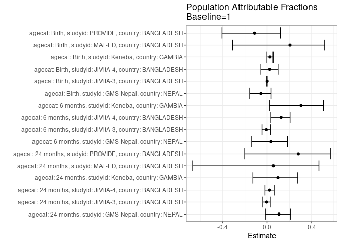

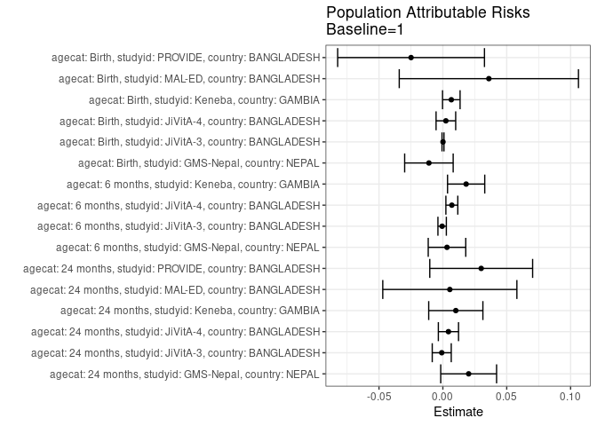

## Results Table

### Parameter: TSM

| agecat | studyid | country | intervention_level | baseline_level | estimate | ci_lower | ci_upper |
| --- | --- | --- | --- | --- | --- | --- | --- |
| Birth | GMS-Nepal | NEPAL | 1 | NA | 0.2063152 | 0.1659446 | 0.2466857 |
| Birth | GMS-Nepal | NEPAL | 0 | NA | 0.1501828 | 0.0870477 | 0.2133180 |
| Birth | JiVitA-3 | BANGLADESH | 1 | NA | 0.1111165 | 0.1047317 | 0.1175012 |
| Birth | JiVitA-3 | BANGLADESH | 0 | NA | 0.1115339 | 0.1047019 | 0.1183659 |
| Birth | JiVitA-4 | BANGLADESH | 1 | NA | 0.0979033 | 0.0809014 | 0.1149051 |
| Birth | JiVitA-4 | BANGLADESH | 0 | NA | 0.1115385 | 0.0745660 | 0.1485110 |
| Birth | Keneba | GAMBIA | 1 | NA | 0.2428124 | 0.2192919 | 0.2663329 |
| Birth | Keneba | GAMBIA | 0 | NA | 0.2516193 | 0.2277839 | 0.2754546 |
| Birth | MAL-ED | BANGLADESH | 1 | NA | 0.1392432 | 0.0566889 | 0.2217976 |
| Birth | MAL-ED | BANGLADESH | 0 | NA | 0.1967688 | 0.1252500 | 0.2682876 |
| Birth | PROVIDE | BANGLADESH | 1 | NA | 0.2448124 | 0.1753720 | 0.3142528 |
| Birth | PROVIDE | BANGLADESH | 0 | NA | 0.2102464 | 0.1692650 | 0.2512278 |
| 6 months | GMS-Nepal | NEPAL | 1 | NA | 0.0881713 | 0.0604846 | 0.1158580 |
| 6 months | GMS-Nepal | NEPAL | 0 | NA | 0.0959935 | 0.0457995 | 0.1461875 |
| 6 months | JiVitA-3 | BANGLADESH | 1 | NA | 0.0869839 | 0.0797012 | 0.0942665 |
| 6 months | JiVitA-3 | BANGLADESH | 0 | NA | 0.0850888 | 0.0728503 | 0.0973273 |
| 6 months | JiVitA-4 | BANGLADESH | 1 | NA | 0.0493401 | 0.0392242 | 0.0594559 |
| 6 months | JiVitA-4 | BANGLADESH | 0 | NA | 0.0813738 | 0.0623430 | 0.1004045 |
| 6 months | Keneba | GAMBIA | 1 | NA | 0.0415210 | 0.0254821 | 0.0575598 |
| 6 months | Keneba | GAMBIA | 0 | NA | 0.0677492 | 0.0541786 | 0.0813199 |
| 24 months | GMS-Nepal | NEPAL | 1 | NA | 0.1717002 | 0.1323464 | 0.2110540 |
| 24 months | GMS-Nepal | NEPAL | 0 | NA | 0.2553008 | 0.1745681 | 0.3360335 |
| 24 months | JiVitA-3 | BANGLADESH | 1 | NA | 0.2203337 | 0.2046892 | 0.2359781 |
| 24 months | JiVitA-3 | BANGLADESH | 0 | NA | 0.2161798 | 0.1873599 | 0.2449998 |
| 24 months | JiVitA-4 | BANGLADESH | 1 | NA | 0.1908939 | 0.1755225 | 0.2062653 |
| 24 months | JiVitA-4 | BANGLADESH | 0 | NA | 0.2095270 | 0.1749163 | 0.2441377 |
| 24 months | Keneba | GAMBIA | 1 | NA | 0.0955444 | 0.0698268 | 0.1212620 |
| 24 months | Keneba | GAMBIA | 0 | NA | 0.1102973 | 0.0910627 | 0.1295318 |
| 24 months | MAL-ED | BANGLADESH | 1 | NA | 0.0921053 | 0.0269330 | 0.1572776 |
| 24 months | MAL-ED | BANGLADESH | 0 | NA | 0.1007752 | 0.0487006 | 0.1528498 |
| 24 months | PROVIDE | BANGLADESH | 1 | NA | 0.0770604 | 0.0336887 | 0.1204321 |
| 24 months | PROVIDE | BANGLADESH | 0 | NA | 0.1174740 | 0.0874000 | 0.1475481 |

### Parameter: E(Y)

| agecat | studyid | country | intervention_level | baseline_level | estimate | ci_lower | ci_upper |
| --- | --- | --- | --- | --- | --- | --- | --- |
| Birth | GMS-Nepal | NEPAL | NA | NA | 0.1954023 | 0.1613549 | 0.2294497 |
| Birth | JiVitA-3 | BANGLADESH | NA | NA | 0.1112249 | 0.1049045 | 0.1175452 |
| Birth | JiVitA-4 | BANGLADESH | NA | NA | 0.1002698 | 0.0846581 | 0.1158815 |
| Birth | Keneba | GAMBIA | NA | NA | 0.2494348 | 0.2261459 | 0.2727237 |
| Birth | MAL-ED | BANGLADESH | NA | NA | 0.1752577 | 0.1216204 | 0.2288951 |
| Birth | PROVIDE | BANGLADESH | NA | NA | 0.2199248 | 0.1846953 | 0.2551543 |
| 6 months | GMS-Nepal | NEPAL | NA | NA | 0.0914077 | 0.0672348 | 0.1155805 |
| 6 months | JiVitA-3 | BANGLADESH | NA | NA | 0.0864198 | 0.0802086 | 0.0926309 |
| 6 months | JiVitA-4 | BANGLADESH | NA | NA | 0.0563743 | 0.0475411 | 0.0652074 |
| 6 months | Keneba | GAMBIA | NA | NA | 0.0597484 | 0.0491105 | 0.0703864 |
| 24 months | GMS-Nepal | NEPAL | NA | NA | 0.1918977 | 0.1562203 | 0.2275751 |
| 24 months | JiVitA-3 | BANGLADESH | NA | NA | 0.2194592 | 0.2057462 | 0.2331723 |
| 24 months | JiVitA-4 | BANGLADESH | NA | NA | 0.1952677 | 0.1809764 | 0.2095589 |
| 24 months | Keneba | GAMBIA | NA | NA | 0.1056803 | 0.0901896 | 0.1211711 |
| 24 months | MAL-ED | BANGLADESH | NA | NA | 0.0975610 | 0.0568436 | 0.1382784 |
| 24 months | PROVIDE | BANGLADESH | NA | NA | 0.1070812 | 0.0818727 | 0.1322897 |

### Parameter: RR

| agecat | studyid | country | intervention_level | baseline_level | estimate | ci_lower | ci_upper |
| --- | --- | --- | --- | --- | --- | --- | --- |
| Birth | GMS-Nepal | NEPAL | 1 | 1 | 1.0000000 | 1.0000000 | 1.000000 |
| Birth | GMS-Nepal | NEPAL | 0 | 1 | 0.7279291 | 0.4575496 | 1.158084 |
| Birth | JiVitA-3 | BANGLADESH | 1 | 1 | 1.0000000 | 1.0000000 | 1.000000 |
| Birth | JiVitA-3 | BANGLADESH | 0 | 1 | 1.0037566 | 0.9724419 | 1.036080 |
| Birth | JiVitA-4 | BANGLADESH | 1 | 1 | 1.0000000 | 1.0000000 | 1.000000 |
| Birth | JiVitA-4 | BANGLADESH | 0 | 1 | 1.1392726 | 0.7861050 | 1.651105 |
| Birth | Keneba | GAMBIA | 1 | 1 | 1.0000000 | 1.0000000 | 1.000000 |
| Birth | Keneba | GAMBIA | 0 | 1 | 1.0362703 | 0.9946440 | 1.079639 |
| Birth | MAL-ED | BANGLADESH | 1 | 1 | 1.0000000 | 1.0000000 | 1.000000 |
| Birth | MAL-ED | BANGLADESH | 0 | 1 | 1.4131300 | 0.7040843 | 2.836218 |
| Birth | PROVIDE | BANGLADESH | 1 | 1 | 1.0000000 | 1.0000000 | 1.000000 |
| Birth | PROVIDE | BANGLADESH | 0 | 1 | 0.8588063 | 0.6097143 | 1.209662 |
| 6 months | GMS-Nepal | NEPAL | 1 | 1 | 1.0000000 | 1.0000000 | 1.000000 |
| 6 months | GMS-Nepal | NEPAL | 0 | 1 | 1.0887160 | 0.5911058 | 2.005229 |
| 6 months | JiVitA-3 | BANGLADESH | 1 | 1 | 1.0000000 | 1.0000000 | 1.000000 |
| 6 months | JiVitA-3 | BANGLADESH | 0 | 1 | 0.9782140 | 0.8266395 | 1.157581 |
| 6 months | JiVitA-4 | BANGLADESH | 1 | 1 | 1.0000000 | 1.0000000 | 1.000000 |
| 6 months | JiVitA-4 | BANGLADESH | 0 | 1 | 1.6492427 | 1.2084737 | 2.250774 |
| 6 months | Keneba | GAMBIA | 1 | 1 | 1.0000000 | 1.0000000 | 1.000000 |
| 6 months | Keneba | GAMBIA | 0 | 1 | 1.6316876 | 1.0561582 | 2.520839 |
| 24 months | GMS-Nepal | NEPAL | 1 | 1 | 1.0000000 | 1.0000000 | 1.000000 |
| 24 months | GMS-Nepal | NEPAL | 0 | 1 | 1.4868987 | 1.0069642 | 2.195578 |
| 24 months | JiVitA-3 | BANGLADESH | 1 | 1 | 1.0000000 | 1.0000000 | 1.000000 |
| 24 months | JiVitA-3 | BANGLADESH | 0 | 1 | 0.9811477 | 0.8434312 | 1.141351 |
| 24 months | JiVitA-4 | BANGLADESH | 1 | 1 | 1.0000000 | 1.0000000 | 1.000000 |
| 24 months | JiVitA-4 | BANGLADESH | 0 | 1 | 1.0976099 | 0.9161967 | 1.314944 |
| 24 months | Keneba | GAMBIA | 1 | 1 | 1.0000000 | 1.0000000 | 1.000000 |
| 24 months | Keneba | GAMBIA | 0 | 1 | 1.1544088 | 0.8386975 | 1.588963 |
| 24 months | MAL-ED | BANGLADESH | 1 | 1 | 1.0000000 | 1.0000000 | 1.000000 |
| 24 months | MAL-ED | BANGLADESH | 0 | 1 | 1.0941307 | 0.4555621 | 2.627791 |
| 24 months | PROVIDE | BANGLADESH | 1 | 1 | 1.0000000 | 1.0000000 | 1.000000 |
| 24 months | PROVIDE | BANGLADESH | 0 | 1 | 1.5244417 | 0.8216206 | 2.828462 |

### Parameter: PAR

| agecat | studyid | country | intervention_level | baseline_level | estimate | ci_lower | ci_upper |
| --- | --- | --- | --- | --- | --- | --- | --- |
| Birth | GMS-Nepal | NEPAL | 1 | NA | -0.0109129 | -0.0299063 | 0.0080806 |
| Birth | JiVitA-3 | BANGLADESH | 1 | NA | 0.0001084 | -0.0006627 | 0.0008794 |
| Birth | JiVitA-4 | BANGLADESH | 1 | NA | 0.0023665 | -0.0053112 | 0.0100442 |
| Birth | Keneba | GAMBIA | 1 | NA | 0.0066224 | -0.0002398 | 0.0134846 |
| Birth | MAL-ED | BANGLADESH | 1 | NA | 0.0360145 | -0.0341421 | 0.1061711 |
| Birth | PROVIDE | BANGLADESH | 1 | NA | -0.0248876 | -0.0823543 | 0.0325791 |
| 6 months | GMS-Nepal | NEPAL | 1 | NA | 0.0032364 | -0.0114552 | 0.0179280 |
| 6 months | JiVitA-3 | BANGLADESH | 1 | NA | -0.0005641 | -0.0038596 | 0.0027314 |
| 6 months | JiVitA-4 | BANGLADESH | 1 | NA | 0.0070342 | 0.0023699 | 0.0116985 |
| 6 months | Keneba | GAMBIA | 1 | NA | 0.0182275 | 0.0036650 | 0.0327899 |
| 24 months | GMS-Nepal | NEPAL | 1 | NA | 0.0201975 | -0.0016644 | 0.0420594 |
| 24 months | JiVitA-3 | BANGLADESH | 1 | NA | -0.0008744 | -0.0083144 | 0.0065656 |
| 24 months | JiVitA-4 | BANGLADESH | 1 | NA | 0.0043738 | -0.0035281 | 0.0122757 |
| 24 months | Keneba | GAMBIA | 1 | NA | 0.0101359 | -0.0110736 | 0.0313455 |
| 24 months | MAL-ED | BANGLADESH | 1 | NA | 0.0054557 | -0.0470421 | 0.0579535 |
| 24 months | PROVIDE | BANGLADESH | 1 | NA | 0.0300208 | -0.0102393 | 0.0702809 |

### Parameter: PAF

| agecat | studyid | country | intervention_level | baseline_level | estimate | ci_lower | ci_upper |
| --- | --- | --- | --- | --- | --- | --- | --- |
| Birth | GMS-Nepal | NEPAL | 1 | NA | -0.0558482 | -0.1572922 | 0.0367036 |
| Birth | JiVitA-3 | BANGLADESH | 1 | NA | 0.0009745 | -0.0059836 | 0.0078844 |
| Birth | JiVitA-4 | BANGLADESH | 1 | NA | 0.0236013 | -0.0559215 | 0.0971352 |
| Birth | Keneba | GAMBIA | 1 | NA | 0.0265497 | -0.0011790 | 0.0535104 |
| Birth | MAL-ED | BANGLADESH | 1 | NA | 0.2054945 | -0.3095212 | 0.5179620 |
| Birth | PROVIDE | BANGLADESH | 1 | NA | -0.1131641 | -0.4069000 | 0.1192450 |
| 6 months | GMS-Nepal | NEPAL | 1 | NA | 0.0354060 | -0.1392849 | 0.1833108 |
| 6 months | JiVitA-3 | BANGLADESH | 1 | NA | -0.0065275 | -0.0453532 | 0.0308561 |
| 6 months | JiVitA-4 | BANGLADESH | 1 | NA | 0.1247768 | 0.0348466 | 0.2063276 |
| 6 months | Keneba | GAMBIA | 1 | NA | 0.3050704 | 0.0215296 | 0.5064469 |
| 24 months | GMS-Nepal | NEPAL | 1 | NA | 0.1052513 | -0.0152704 | 0.2114660 |
| 24 months | JiVitA-3 | BANGLADESH | 1 | NA | -0.0039844 | -0.0384641 | 0.0293505 |
| 24 months | JiVitA-4 | BANGLADESH | 1 | NA | 0.0223990 | -0.0187214 | 0.0618596 |
| 24 months | Keneba | GAMBIA | 1 | NA | 0.0959113 | -0.1286597 | 0.2757990 |
| 24 months | MAL-ED | BANGLADESH | 1 | NA | 0.0559211 | -0.6686320 | 0.4658588 |
| 24 months | PROVIDE | BANGLADESH | 1 | NA | 0.2803557 | -0.2025792 | 0.5693524 |